# GetDist Jupyter Notebook Plot Gallery

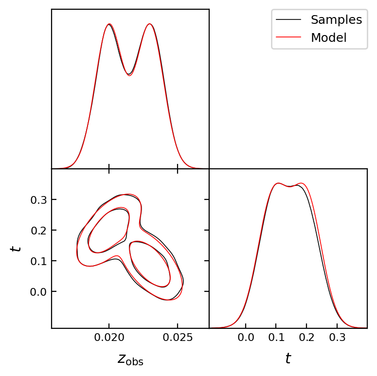

```python
# You can also explicitly name parameters so Gaussian mixtures can be plotted
# in combination with samples
from getdist.gaussian_mixtures import Mixture2D

cov1 = [[0.001**2, 0.0006 * 0.05], [0.0006 * 0.05, 0.05**2]]
cov2 = [[0.001**2, -0.0006 * 0.05], [-0.0006 * 0.05, 0.05**2]]
mean1 = [0.02, 0.2]
mean2 = [0.023, 0.09]
mixture = Mixture2D([mean1, mean2], [cov1, cov2], names=["zobs", "t"], labels=[r"z_{\rm obs}", "t"], label="Model")

# Generate samples from the mixture as simple example
mix_samples = mixture.MCSamples(3000, label="Samples")

g = plots.get_subplot_plotter()
# compare the analytic mixture to the sample density
g.triangle_plot([mix_samples, mixture], filled=False)
```

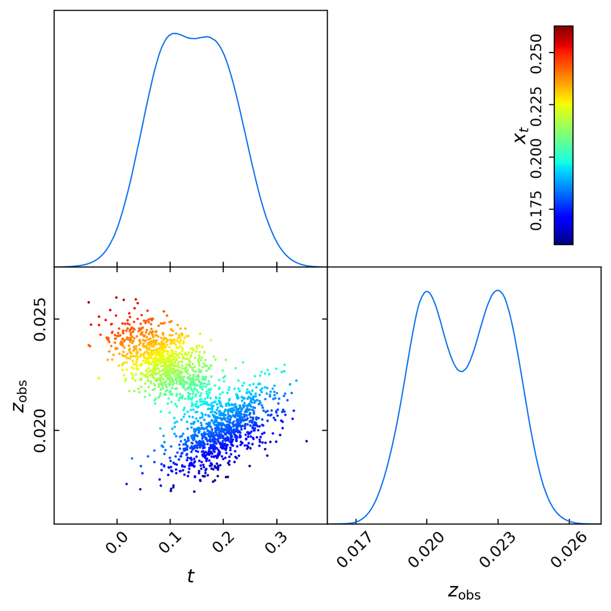

```python
# For long tick labels GetDist will space them intelligently so they don't overlap.
# You can also rotate tick labels
p = mix_samples.getParams()
mix_samples.addDerived(10 * p.zobs - p.t / 10, name="xt", label="x_t")

g = plots.get_subplot_plotter(subplot_size=3)
g.settings.axes_fontsize = 12
g.settings.axis_tick_x_rotation = 45
g.settings.axis_tick_y_rotation = 90
g.settings.colorbar_tick_rotation = 90
g.triangle_plot(mix_samples, ["t", "zobs"], plot_3d_with_param="xt", filled=True)
```

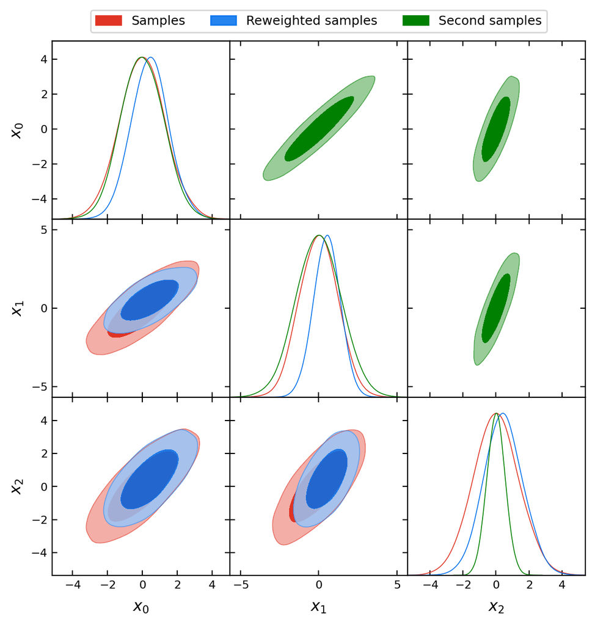

```python
# Double triangle plot
g = plots.get_subplot_plotter()
g.triangle_plot(
    [samples, new_samples],
    ["x0", "x1", "x2"],
    filled=True,
    upper_roots=[samples2],
    upper_kwargs={"contour_colors": ["green"]},
    legend_labels=["Samples", "Reweighted samples", "Second samples"],
);
```

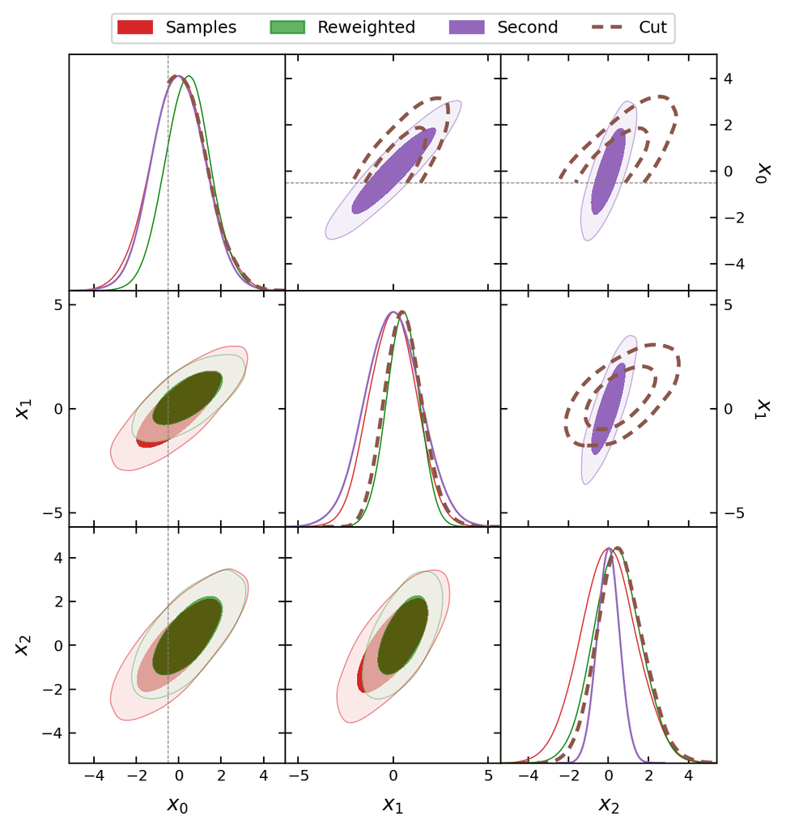

```python
# Variants
from matplotlib import cm

g = plots.get_subplot_plotter()

upper_kwargs = {
    "contour_colors": cm.tab10.colors[4:],
    "contour_ls": ["-", "--"],
    "filled": [True, False],
    "show_1d": [True, True],
    "contour_lws": [1, 2],
}
g.settings.solid_contour_palefactor = 0.9
g.settings.alpha_filled_add = 0.6
g.triangle_plot(
    [samples, new_samples],
    ["x0", "x1", "x2"],
    filled=True,
    contour_colors=["C3", "green"],
    markers={"x0": -0.5},
    upper_roots=[samples2, cut_samples],
    upper_kwargs=upper_kwargs,
    upper_label_right=True,
    legend_labels=["Samples", "Reweighted", "Second", "Cut"],
);
```

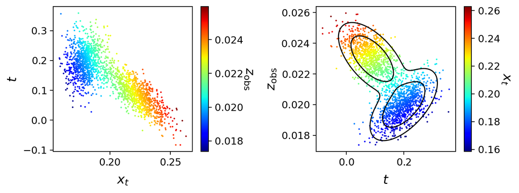

```python
# Sets of 3D plots
g = plots.get_subplot_plotter(width_inch=8)
g.plots_3d(mix_samples, [["xt", "t", "zobs"], ["t", "zobs", "xt"]], nx=2)
# and this is how to manually add contours only to a specific plot
g.add_2d_contours(mixture, "t", "zobs", ax=[0, 1]);
```

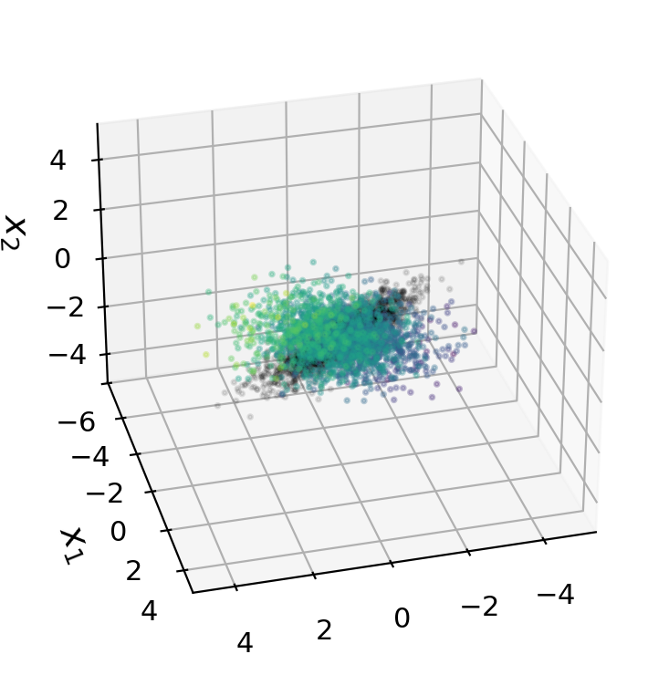

```python
# 4D x-y-z-color scatter plots:
# Use ""%matplotlib notebook" to interactively rotate etc.

g = plots.get_single_plotter()
g.plot_4d(
    [samples, samples2],
    ["x0", "x1", "x2", "x3"],
    cmap="viridis",
    color_bar=False,
    azim=75,
    alpha=[0.3, 0.1],
    shadow_color=False,
    compare_colors=["k"],
)
```

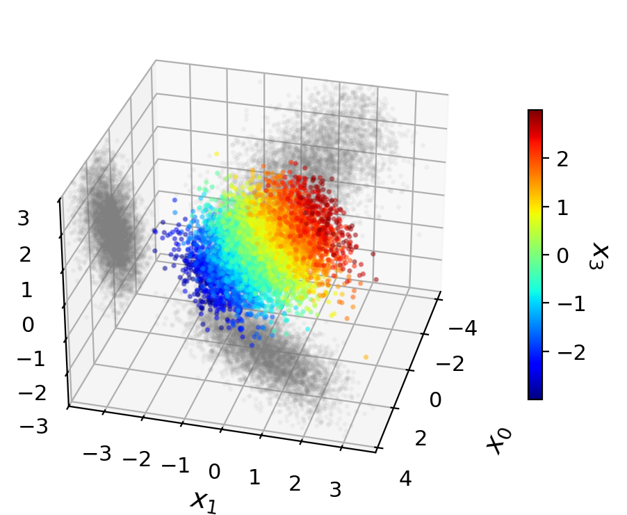

```python
# with projection onto axes, colorbar, custom limits, colors, etc.
g = plots.get_single_plotter()
g.plot_4d(
    samples,
    ["x0", "x1", "x2", "x3"],
    cmap="jet",
    alpha=0.4,
    shadow_alpha=0.05,
    shadow_color=True,
    max_scatter_points=6000,
    lims={"x2": (-3, 3), "x3": (-3, 3)},
    colorbar_args={"shrink": 0.6},
)
```

```python
# use animate=True and mp4_filename option to export an rotation animation
# this shows example output

from IPython.display import Video

Video("https://cdn.cosmologist.info/antony/sample_rotation.mp4", html_attributes="controls loop", width=600)
```

[video not shown]

**Using styles to change settings for consistent plot scripts**

If you want to change several default settings, you can make a module containing a new plotter class, which defines its own settings and behaviour, and then use it as a style. A couple of sample styles are included: getdist.styles.tab10 and getdist.styles.planck. Using the same style in each script will then give consistent outputs without changing settings each time.

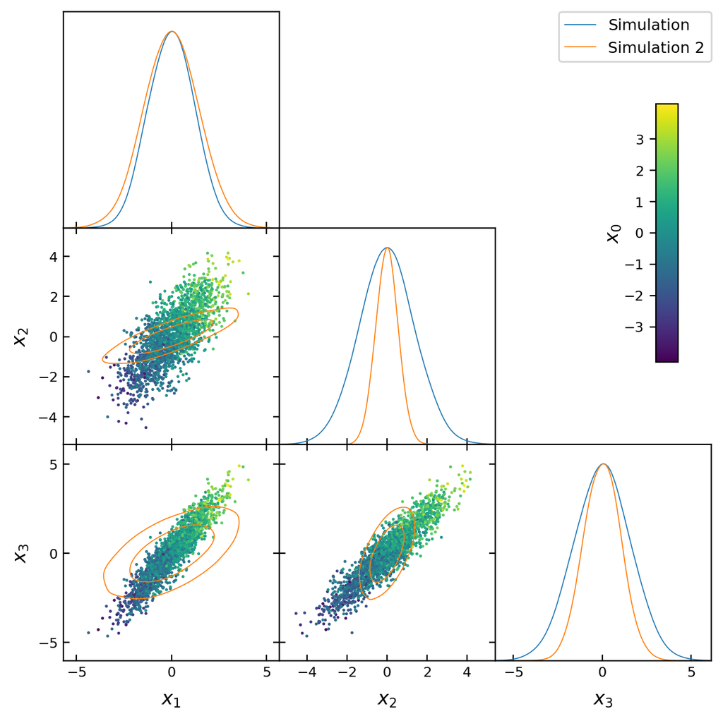

```python
# use the 'tab10' style, which uses default matplotlib colourmaps
from getdist.styles.tab10 import style_name

plots.set_active_style(style_name)

g = plots.get_subplot_plotter(width_inch=6)
g.triangle_plot(
    [samples, samples2], ["x1", "x2", "x3"], plot_3d_with_param="x0", legend_labels=["Simulation", "Simulation 2"]
)
```

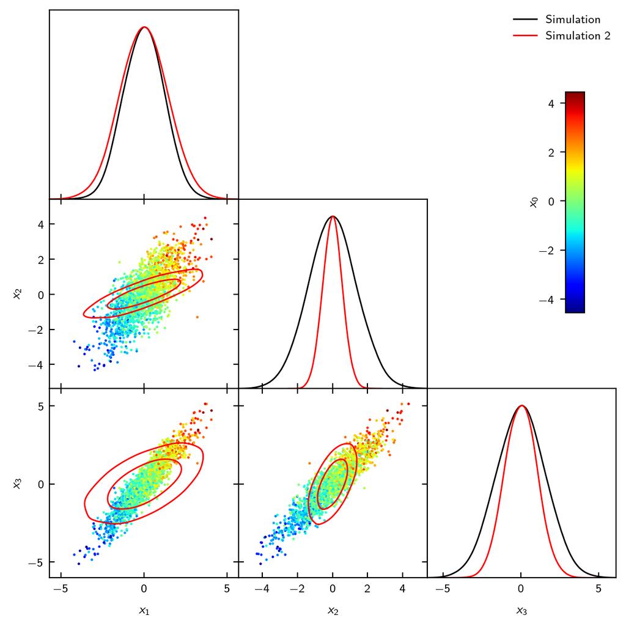

```python
# getdist.styles.planck is a more complicated case which also changes matplotlib style
# (to use latex rendering and different fonts). It also turns of scaling by default so all
# fonts are fixed size.

from getdist.styles.planck import style_name

plots.set_active_style(style_name)

g = plots.get_subplot_plotter(width_inch=6)
g.triangle_plot(
    [samples, samples2], ["x1", "x2", "x3"], plot_3d_with_param="x0", legend_labels=["Simulation", "Simulation 2"]
)
```

```python
# Back to default style
plots.set_active_style();
```

**Getting consistent sizes for publication**